# Coronavirus v Čechách

# Základní statistiky

## Přehled

Základní přehled (testy)

| Datum | Přírustkový počet testů | Kumulativní počet testů | Pozitivita testů (v %) |
| --- | --- | --- | --- |
| 2020-10-22 | 46390 | 1977582 | 30.52 |
| 2020-10-23 | 45223 | 2022805 | 33.73 |
| 2020-10-24 | 39190 | 2061995 | 31.82 |
| 2020-10-25 | 21375 | 2083370 | 34.16 |
| 2020-10-26 | 34946 | 2118316 | 29.40 |

Základní přehled (nákaza)

| Datum | Přírustkový počet nakažených | Kumulativní počet nakažených | Kumulativní počet vyléčených | Kumulativní počet úmrtí |
| --- | --- | --- | --- | --- |
| 2020-10-22 | 14156 | 223071 | 101968 | 1951 |
| 2020-10-23 | 15254 | 238325 | 102884 | 2062 |
| 2020-10-24 | 12471 | 250796 | 103306 | 2184 |
| 2020-10-25 | 7301 | 258097 | 103587 | 2309 |
| 2020-10-26 | 10273 | 268370 | 103952 | 2445 |

Aktuálně hospitalizovaní: `6191`

Podíl nakažených s těžkým průběhem: `3.63`%

## Testy

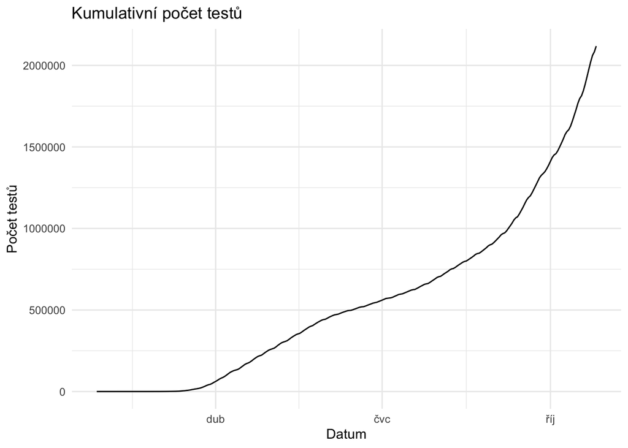

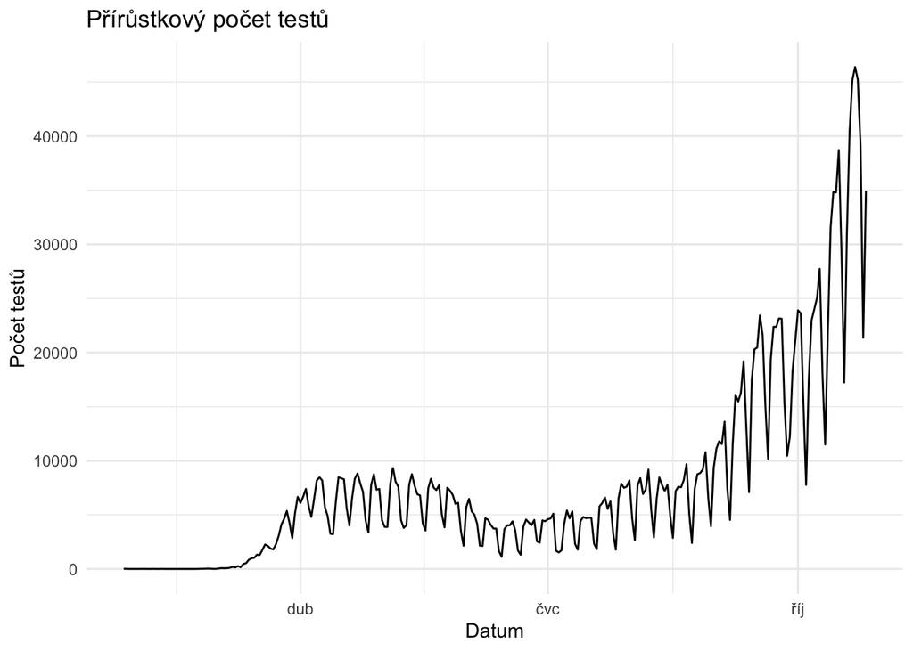

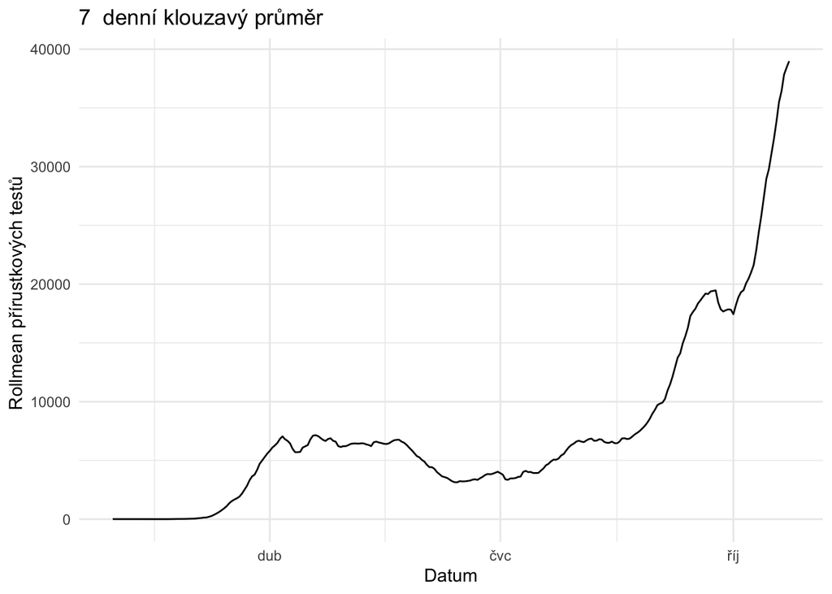

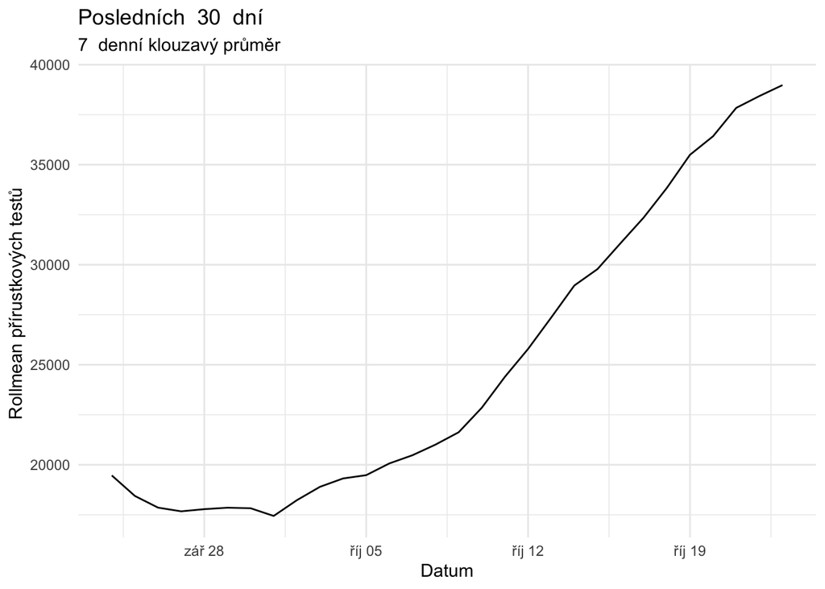

## Pozitivní případy

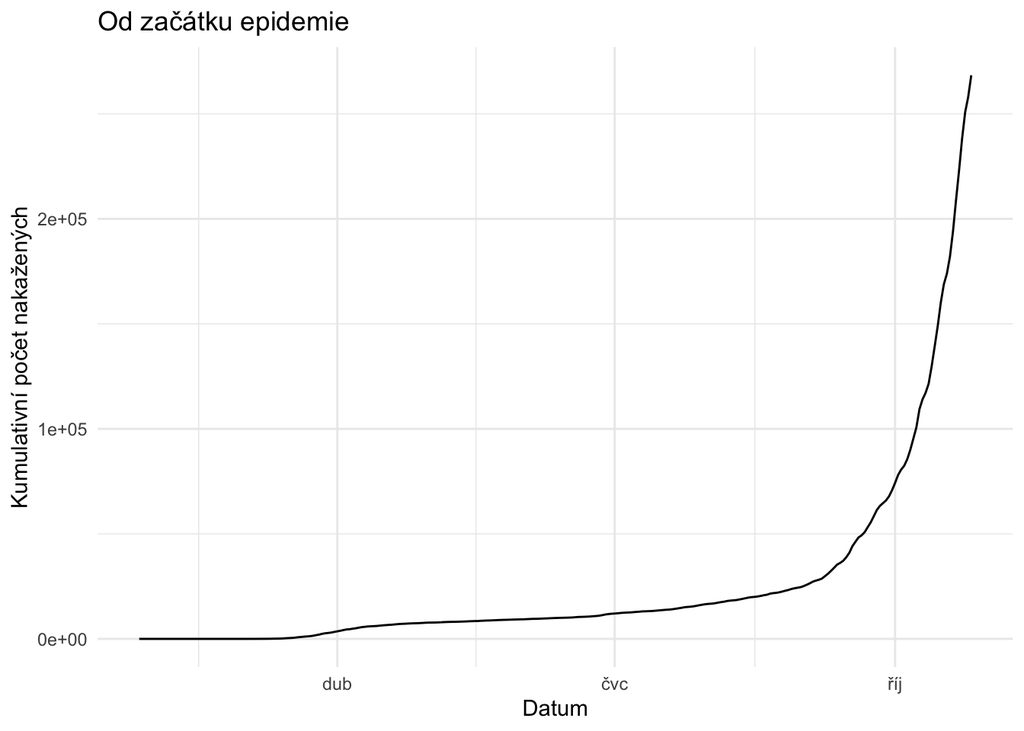

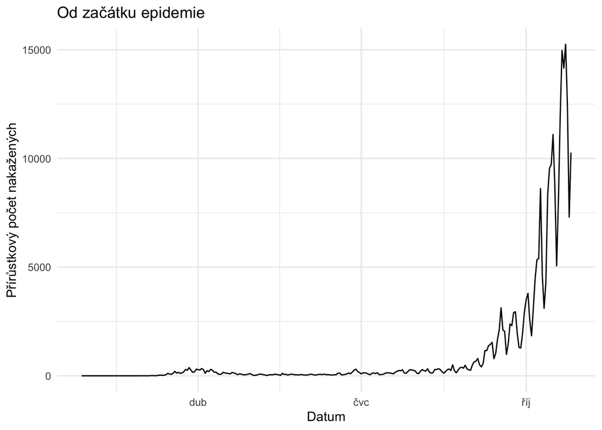

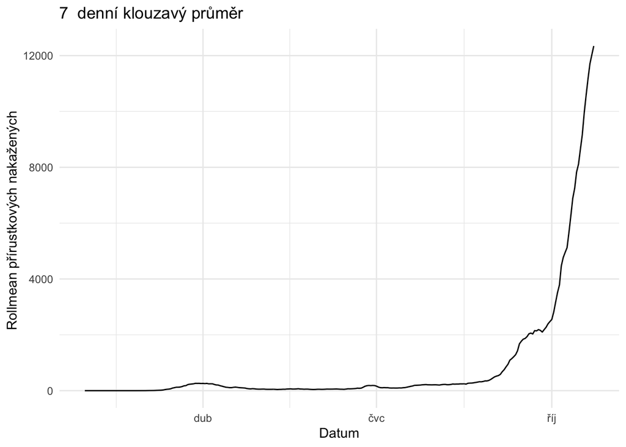

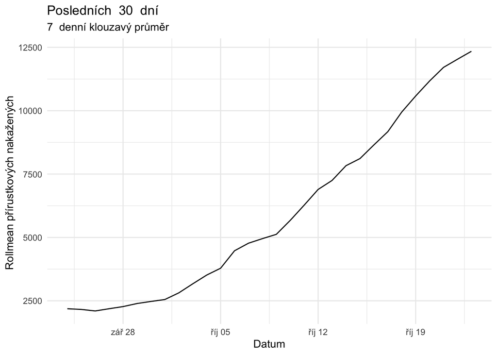

## Podíl pozitivních testů

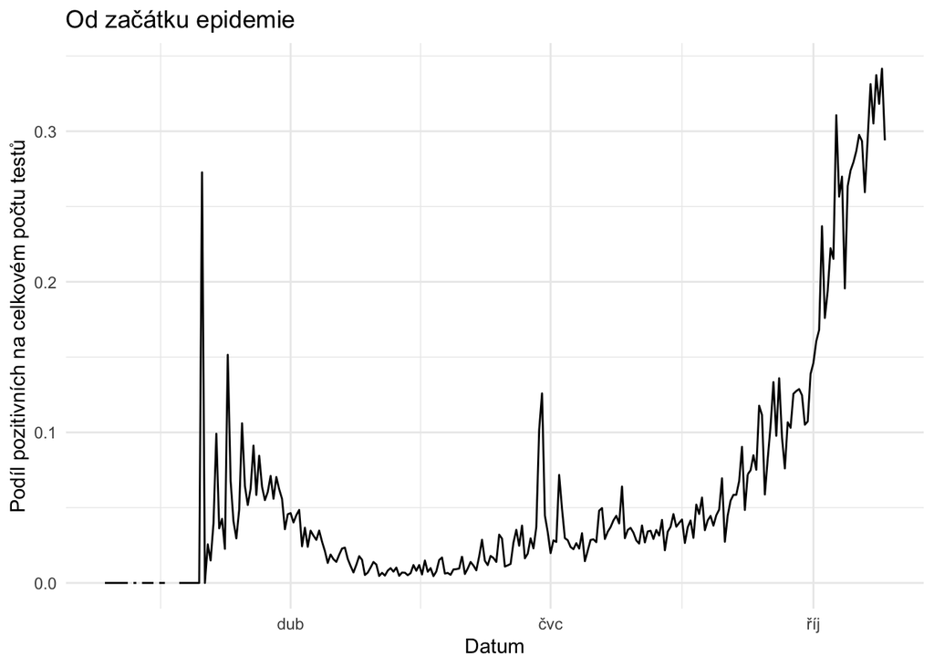

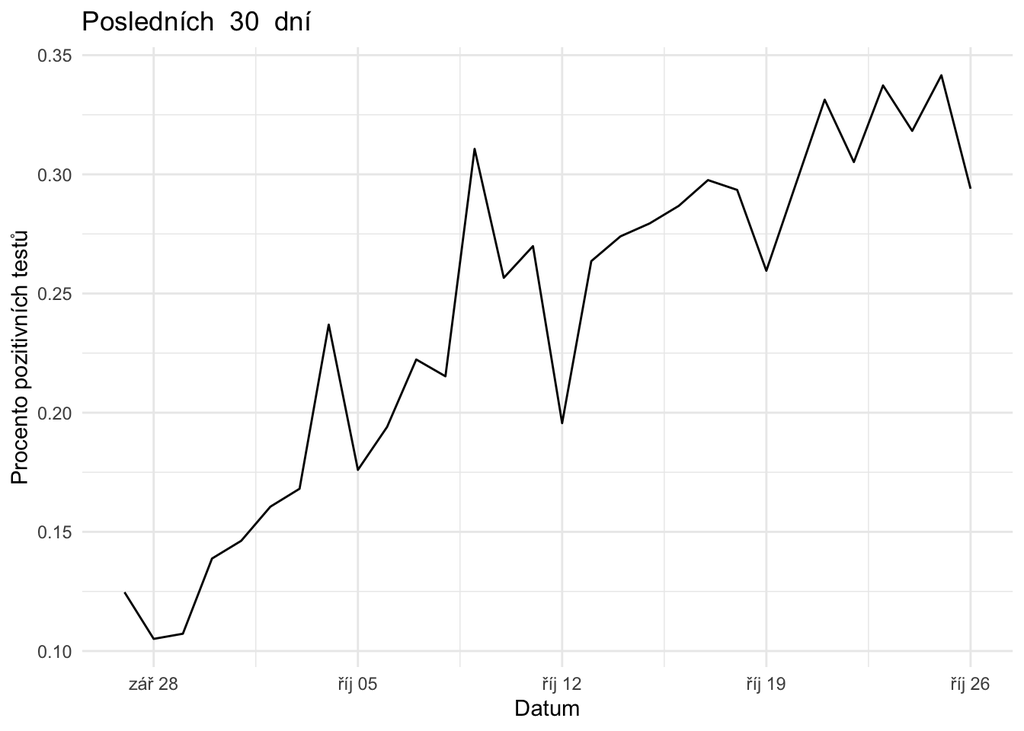

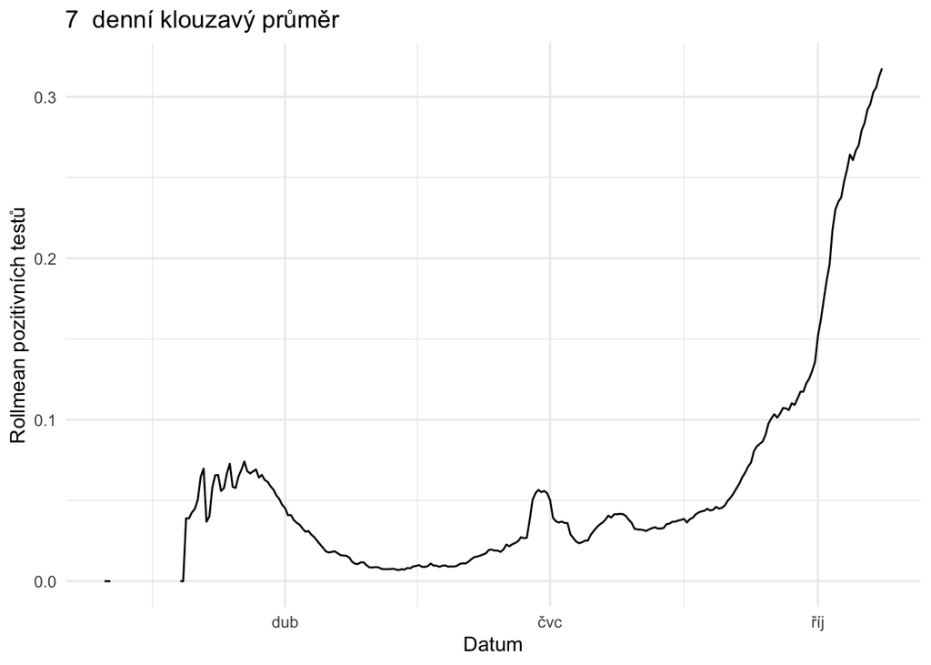

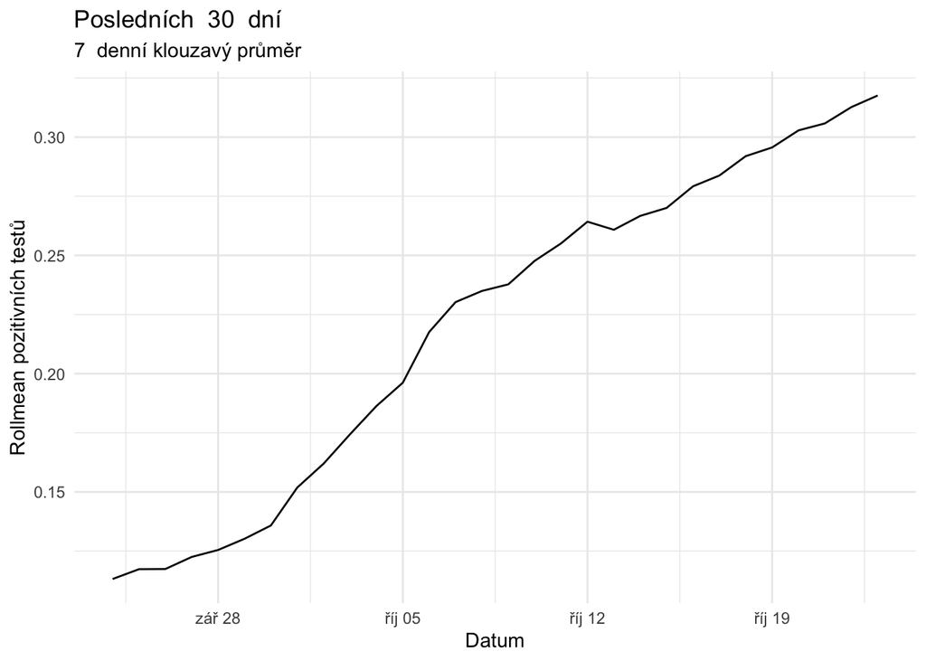

Podíl pozitivních testů na celkovém počtu od začátku epidemie je `12.669` %.

Podíl pozitivních testů na celkovém počtu za posledních 30 dní je `25.892` %.

# Modely

## Linearní model

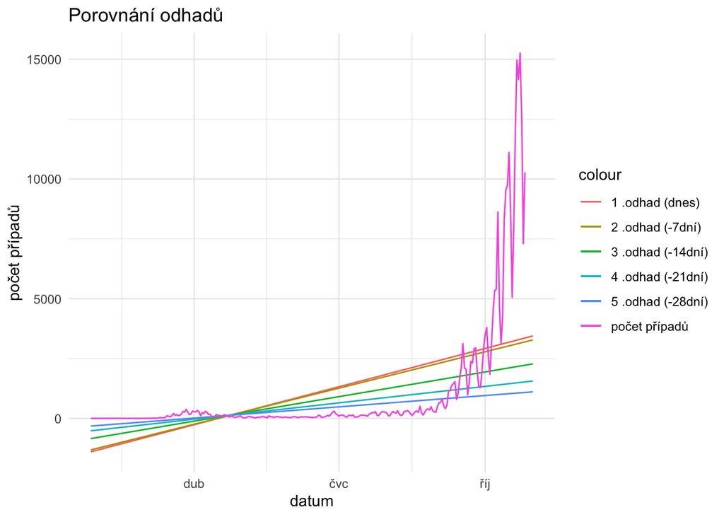

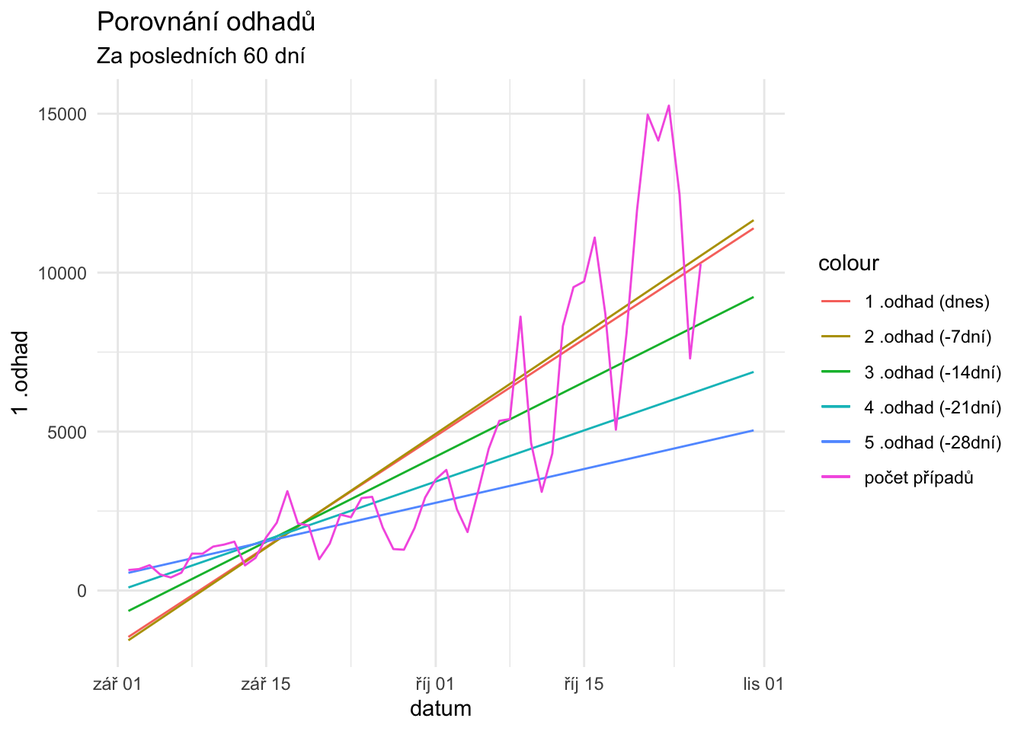

### Data (Lineární model)

#### Od začátku epidemie

Podle lineárního modelu bychom tímto tempem měli dne `2020-10-31` podle

- 1. odhadu `3444` nakažených denně
- 2. odhadu `3277` nakažených denně
- 3. odhadu `2276` nakažených denně
- 4. odhadu `1560` nakažených denně
- 5. odhadu `1108` nakažených denně

#### Za posledních `60` dní

Podle lineárního modelu bychom tímto tempem měli dne `2020-10-31` podle

- 1. odhadu `11395` nakažených denně
- 2. odhadu `11651` nakažených denně
- 3. odhadu `9235` nakažených denně
- 4. odhadu `6876` nakažených denně
- 5. odhadu `5038` nakažených denně

## Kvadratický model

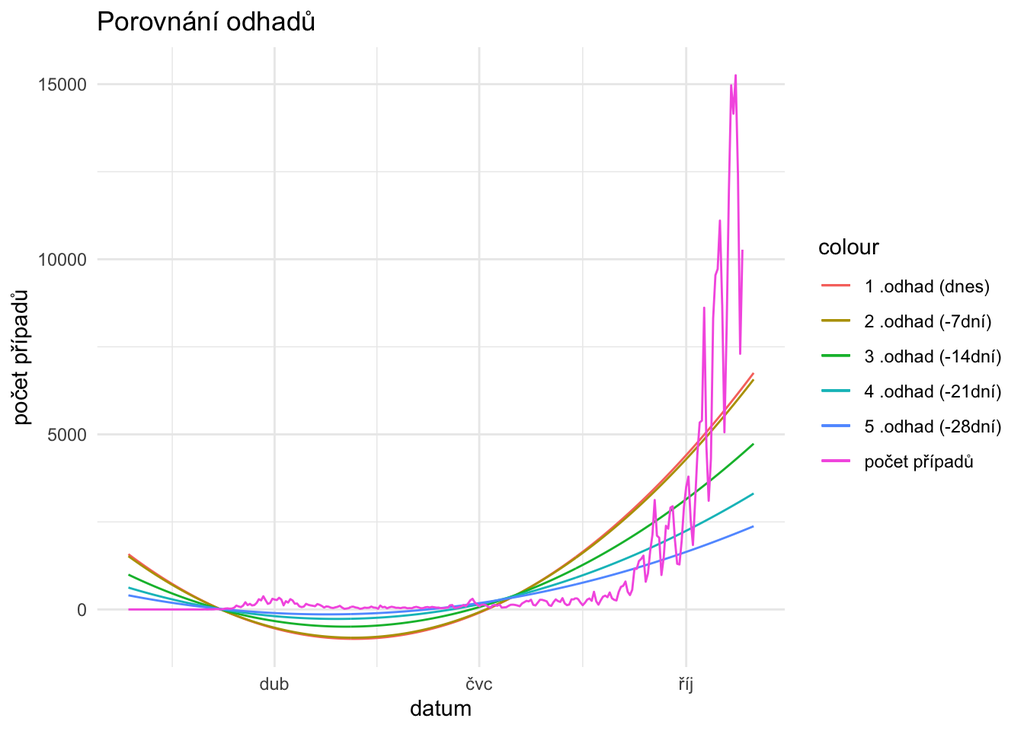

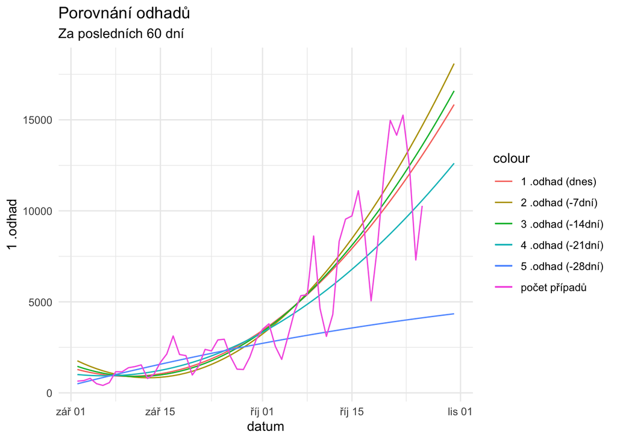

### Data (Kvadratický model)

#### Od začátku epidemie

Podle kvadratického modelu bychom tímto tempem měli dne `2020-10-31` podle

- 1. odhadu `6754` nakažených denně
- 2. odhadu `6569` nakažených denně
- 3. odhadu `4734` nakažených denně
- 4. odhadu `3313` nakažených denně
- 5. odhadu `2376` nakažených denně

#### Za posledních `60` dní

- 1. odhadu `15838` nakažených denně
- 2. odhadu `18089` nakažených denně
- 3. odhadu `16589` nakažených denně
- 4. odhadu `12613` nakažených denně
- 5. odhadu `4345` nakažených denně

## Exponential model

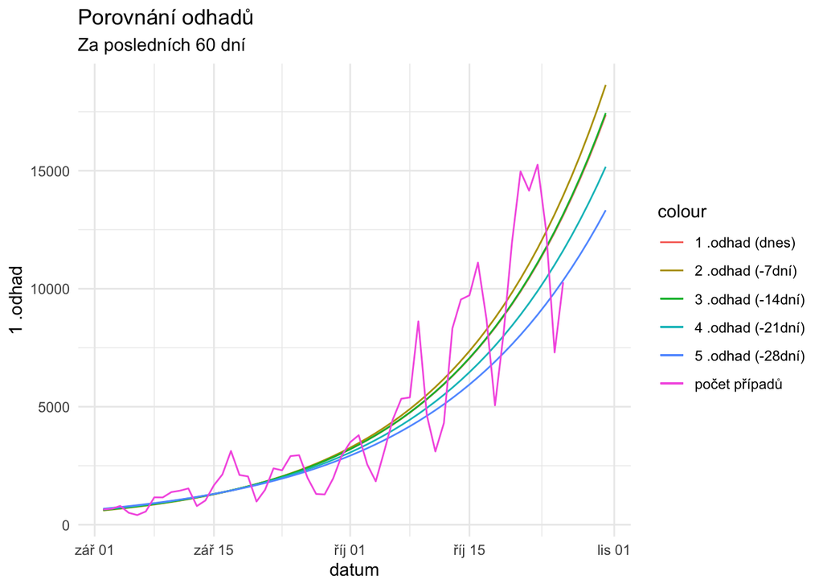

### Data (Exponential model)

#### Za posledních `60` dní

Podle exponencionálního modelu bychom tímto tempem měli dne `2020-10-31` podle

- 1. odhadu `17363` nakažených denně
- 2. odhadu `18633` nakažených denně
- 3. odhadu `17443` nakažených denně
- 4. odhadu `15166` nakažených denně
- 5. odhadu `13327` nakažených denně

Podle exponencionálního modelu bychom tímto tempem měli dnes dne `2020-10-27` podle

- 1. odhadu `13858` nakažených denně
- 2. odhadu `14772` nakažených denně
- 3. odhadu `13915` nakažených denně
- 4. odhadu `12253` nakažených denně
- 5. odhadu `10889` nakažených denně

# SIR MODELY

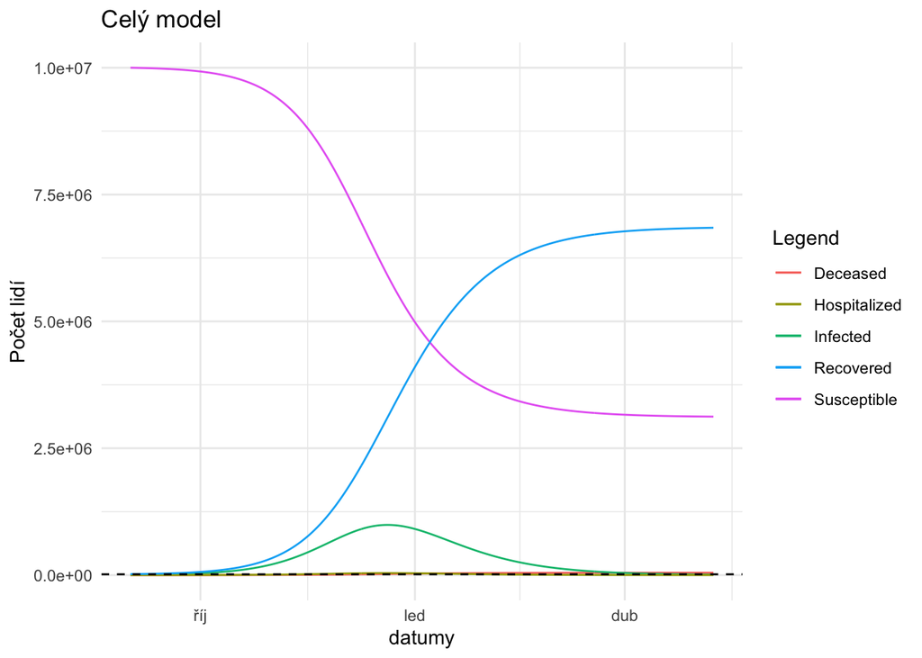

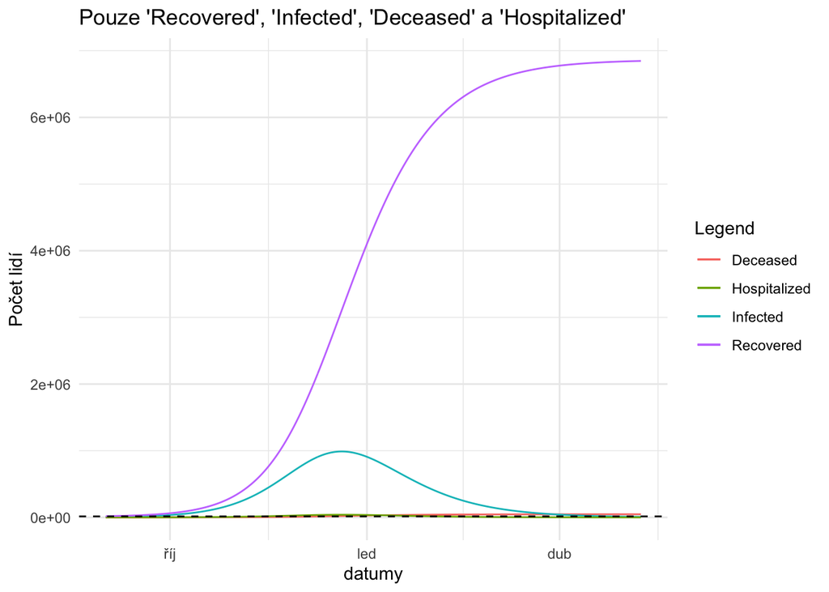

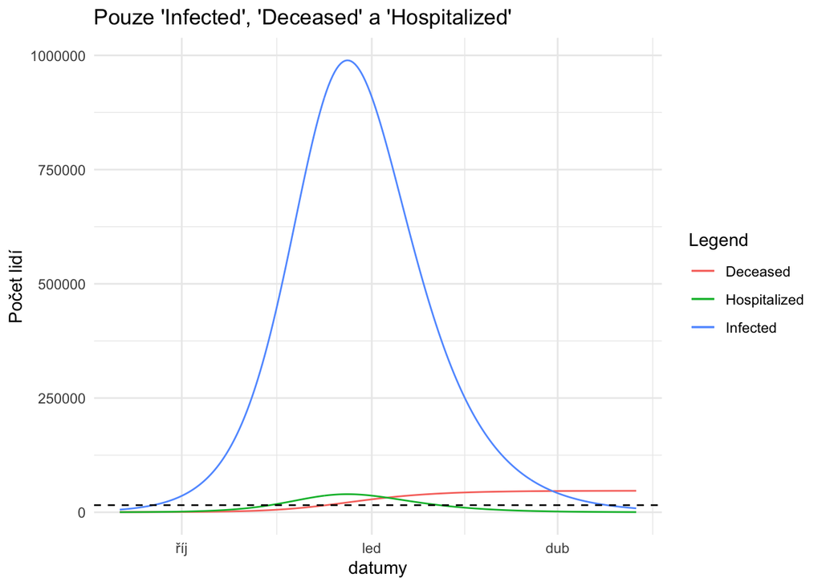

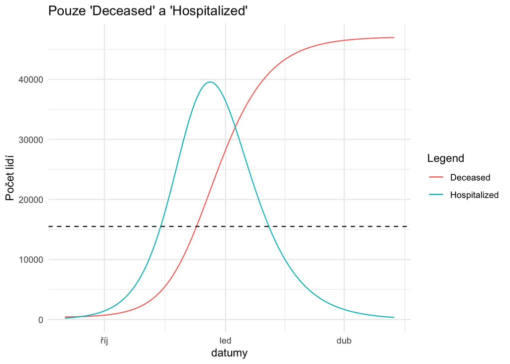

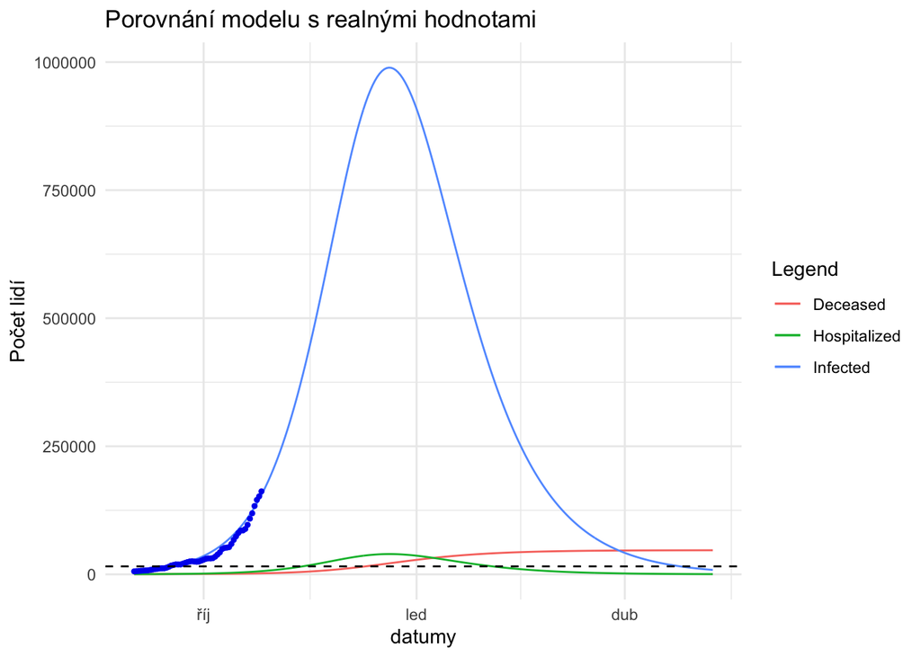

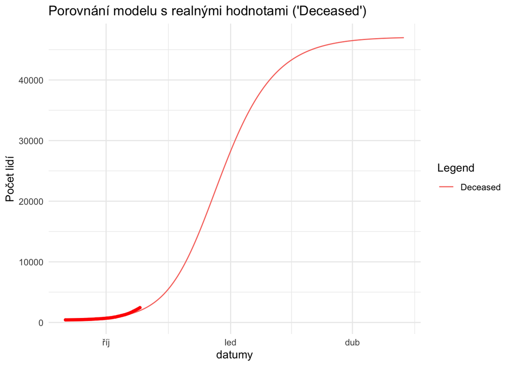

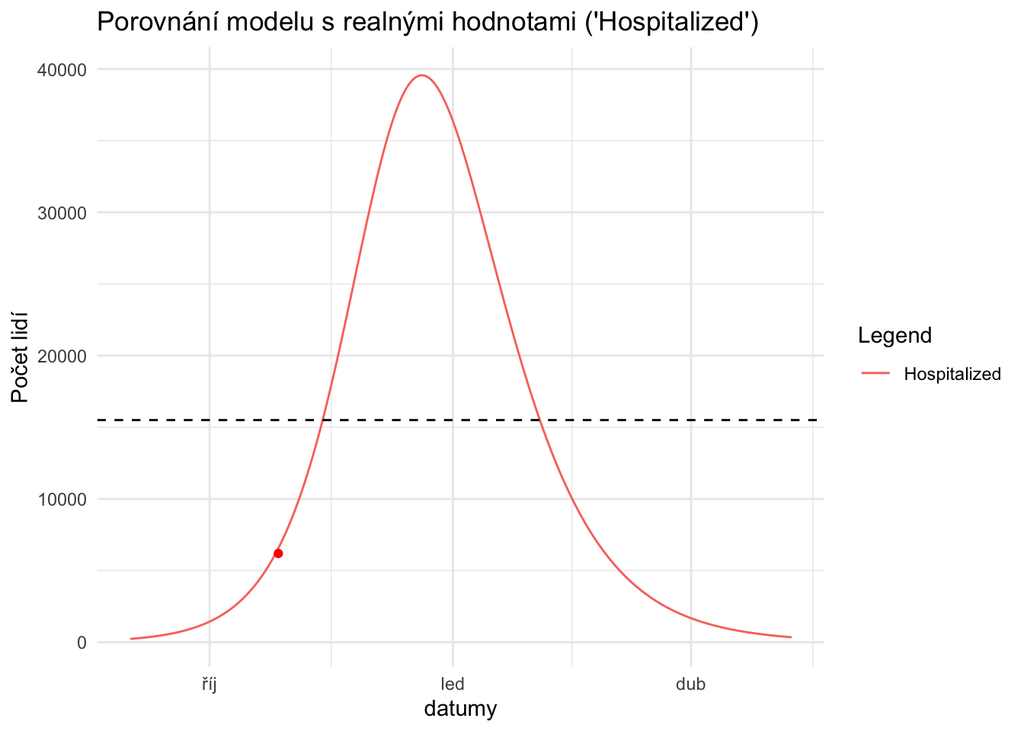

## Informace

`Peak nastane dne 2020-12-20 s počtem nakažených rovnu 989166 a aktuálním počtem hospitalizovných v nemocnicích 39567 lidí.`

`Kapacita nemocnic, která je stanovena na 15500 lůžek, bude při momentálním trendu překročena dne 2020-11-13`

`Celkově Covid-19 prodělá 6846520`

`Počet umrtí se zastaví na čísle 46980`

`Momentální hodnota rho je 1.705`

# Informace

Update proběhl `2020-10-28 00:24:03`.

Poslední data jsou z `2020-10-26` ze stránek ministerstva zdravotnictví ČR (https://onemocneni-aktualne.mzcr.cz/covid-19)